# Health Analytics for Robust Policy

A Guide to Style

September 25, 2023

HARP $\leftrightarrow$ HUB

## Look and Feel

- The `html` pages are generated from R Markdown documents: `pagename.html` is generated by `pagename.Rmd`
- The banner at the top should include links to the HARP landing page, the navigation HUB, and (possibly) other closely related pages.
- The sections use tabset to make the material easy to access. Please use the command `{.tabset .tabset-fade .tabset-pills}`
- The `sandstone` theme is used throughout.

## Writing Style

- `HARP` is a good place to introduce hard concepts in plain language. We hope to emulate the writing style of *Numerical Recipes in C.* In the preface to the $2^{nd}$ edition, the authors described their style in the $1^{st}$ edition as *``…informal, fearlessly editorial, unesoteric, and above all useful.’’*
- The intent of `HARP` is to introduce complex concepts, so please keep it short and aim for one of the following:
  - lecture notes
  - a user’s guide
  - a vignettes that teach a single concept
  - insightful commentary
- If a document is getting too long and complex, consider splitting it up.
- Publish the long version, write the short version here, and add citations. In general, we don’t want long essays or drafts.
- We think academic journals are the best place to put complex analyses, or discussions of highly technical material. Any new methods and new concepts should go through peer review.
- Please use the functionality to embed instructive R-code:

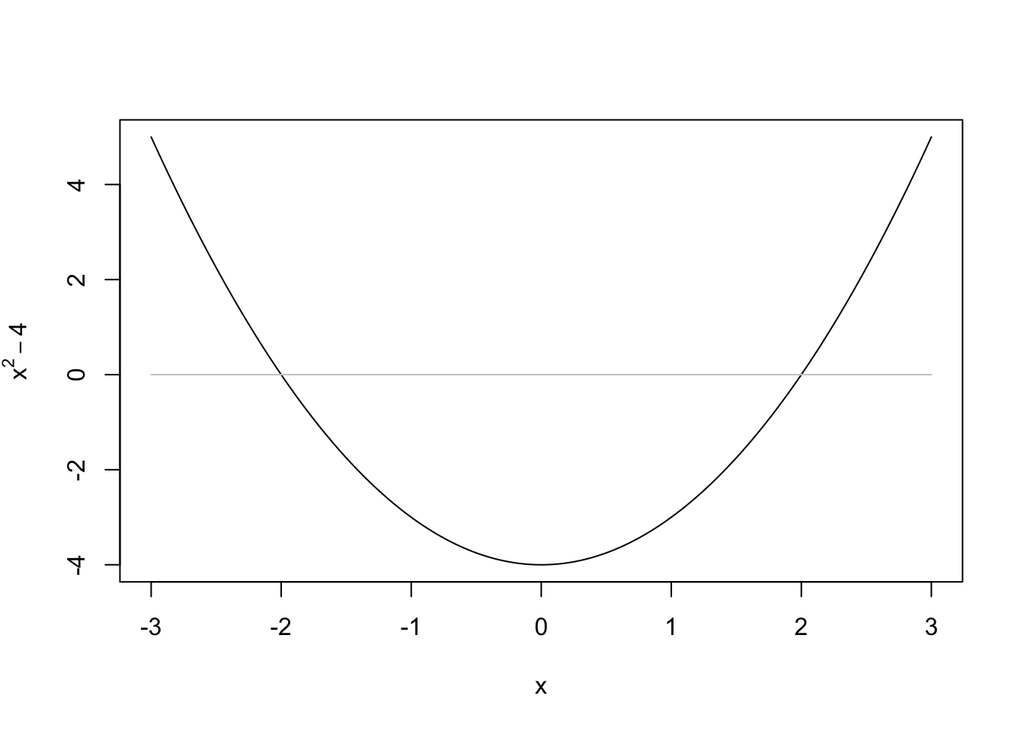

```r
x = seq(-3, 3, length.out=200)
plot(x, x^2-4, type = "l", ylab = expression(x^2-4))
segments(-3, 0, 3, 0, col = grey(0.8))
```

## Citations

- References are strongly encouraged. The bibliography is `refs.bib` using the `plos` citation style. To add a citiation, use `[@cite-key]`.
- If there are any references, the last tab should be called `Refs`. For example, `[@WernsdorferWH1988MalariaPrinciples]` is a citation to *Malaria: Principles and Practice of Malariology* [1].
- If you want to cite something but you can’t find it in `refs.bib,` tell Dave it’s missing and send a link.

## Refs

1.

Wernsdorfer WH, McGregor IA, editors. Malaria: Principles and Practice of Malariology. New York: Churchill Livingstone; 1988. Available: http://www.worldcat.org/title/malaria-principles-and-practice-of-malariology/oclc/15793746